# Impact of covid-19 in mobility

Mohammed ElBelbesy

5/22/2021

**Task:** The company client wants to know which potential markets are the most interesting for the newline of products of sports market and it is interested in knowing the Covid-19 impact on mobility.

**Target/Purpose:** develop a new service or adapt exsisting one depends on the situation

**introduction:** The COVID-19 pandemic influences the behavior of the people. One behavior that changes is mobility. Changes in behavior affect economic conditions in an area. The knowledge gained can be a reference in making accurate and right decisions. These decisions are taken to mitigate the risks and impacts felt by the community. https://iopscience.iop.org/article/10.1088/1742-6596/1833/1/012002/pdf. we want to explore data gained from maps of apple to to make a decision meets our goal for the best potenial market

**Dataset:** The data used is COVID-19 Community Mobility Report. The data is in the form of a table that contains mobility data for each country. Some countries are also equipped with data for each region and subregion. The data displayed includes certain dates that are quite complete.  
we want to explore data gained from maps of apple to to make a decision meets oor goal for the best potenial market

Load in the required R packages

```r
#include= F : runs the code, but does not show the results
library(readr) #importing and reading of data
library(tidyr)
library(dplyr) #for data wrangling and maipulation
library(ggplot2) #for data visualisation
library(visdat) # to visualize the NA Values
```

#### Setting working Directory

```r
getwd()
```

```
## [1] "C:/Users/admin/Documents/data_vis_ss21"
```

```r
setwd("C:/Users/admin/Documents/data_vis_ss21")
```

#### Importing the data and store it in an object

#### Investigating the first 6 observations

```r
head(df) #investigate the first 6 observations
```

```
## # A tibble: 6 x 176
##   geo_type region transportation_~ alternative_name `sub-region` country
##   <chr>    <chr>  <chr>            <chr>            <chr>        <chr>
## 1 country~ Alban~ driving          <NA>             <NA>         <NA>
## 2 country~ Alban~ walking          <NA>             <NA>         <NA>
## 3 country~ Argen~ driving          <NA>             <NA>         <NA>
## 4 country~ Argen~ walking          <NA>             <NA>         <NA>
## 5 country~ Austr~ driving          AU               <NA>         <NA>
## 6 country~ Austr~ transit          AU               <NA>         <NA>
## # ... with 170 more variables: `2020-01-13` <dbl>, `2020-01-14` <dbl>,
## #   `2020-01-15` <dbl>, `2020-01-16` <dbl>, `2020-01-17` <dbl>,
## #   `2020-01-18` <dbl>, `2020-01-19` <dbl>, `2020-01-20` <dbl>,
## #   `2020-01-21` <dbl>, `2020-01-22` <dbl>, `2020-01-23` <dbl>,
## #   `2020-01-24` <dbl>, `2020-01-25` <dbl>, `2020-01-26` <dbl>,
## #   `2020-01-27` <dbl>, `2020-01-28` <dbl>, `2020-01-29` <dbl>,
## #   `2020-01-30` <dbl>, `2020-01-31` <dbl>, `2020-02-01` <dbl>,
## #   `2020-02-02` <dbl>, `2020-02-03` <dbl>, `2020-02-04` <dbl>,
## #   `2020-02-05` <dbl>, `2020-02-06` <dbl>, `2020-02-07` <dbl>,
## #   `2020-02-08` <dbl>, `2020-02-09` <dbl>, `2020-02-10` <dbl>,
## #   `2020-02-11` <dbl>, `2020-02-12` <dbl>, `2020-02-13` <dbl>,
## #   `2020-02-14` <dbl>, `2020-02-15` <dbl>, `2020-02-16` <dbl>,
## #   `2020-02-17` <dbl>, `2020-02-18` <dbl>, `2020-02-19` <dbl>,
## #   `2020-02-20` <dbl>, `2020-02-21` <dbl>, `2020-02-22` <dbl>,
## #   `2020-02-23` <dbl>, `2020-02-24` <dbl>, `2020-02-25` <dbl>,
## #   `2020-02-26` <dbl>, `2020-02-27` <dbl>, `2020-02-28` <dbl>,
## #   `2020-02-29` <dbl>, `2020-03-01` <dbl>, `2020-03-02` <dbl>,
## #   `2020-03-03` <dbl>, `2020-03-04` <dbl>, `2020-03-05` <dbl>,
## #   `2020-03-06` <dbl>, `2020-03-07` <dbl>, `2020-03-08` <dbl>,
## #   `2020-03-09` <dbl>, `2020-03-10` <dbl>, `2020-03-11` <dbl>,
## #   `2020-03-12` <dbl>, `2020-03-13` <dbl>, `2020-03-14` <dbl>,
## #   `2020-03-15` <dbl>, `2020-03-16` <dbl>, `2020-03-17` <dbl>,
## #   `2020-03-18` <dbl>, `2020-03-19` <dbl>, `2020-03-20` <dbl>,
## #   `2020-03-21` <dbl>, `2020-03-22` <dbl>, `2020-03-23` <dbl>,
## #   `2020-03-24` <dbl>, `2020-03-25` <dbl>, `2020-03-26` <dbl>,
## #   `2020-03-27` <dbl>, `2020-03-28` <dbl>, `2020-03-29` <dbl>,
## #   `2020-03-30` <dbl>, `2020-03-31` <dbl>, `2020-04-01` <dbl>,
## #   `2020-04-02` <dbl>, `2020-04-03` <dbl>, `2020-04-04` <dbl>,
## #   `2020-04-05` <dbl>, `2020-04-06` <dbl>, `2020-04-07` <dbl>,
## #   `2020-04-08` <dbl>, `2020-04-09` <dbl>, `2020-04-10` <dbl>,
## #   `2020-04-11` <dbl>, `2020-04-12` <dbl>, `2020-04-13` <dbl>,
## #   `2020-04-14` <dbl>, `2020-04-15` <dbl>, `2020-04-16` <dbl>,
## #   `2020-04-17` <dbl>, `2020-04-18` <dbl>, `2020-04-19` <dbl>,
## #   `2020-04-20` <dbl>, `2020-04-21` <dbl>, ...
```

#### Quick view for our data

```r
View(df)
```

From the data frame, we see can that, the data is not well-constructed. For this reason, we will begin our analysis with a crucial step which is data wrangling(data cleaning and transformation).

#### data cleaning

one important rule to make our dataset tidy is to put each variable (the date) in the same column.

```r
mobility <- df %>%  gather(date, req_num ,"2020-01-13":"2020-06-30")
#with Pipe operator I pass the data to the gather function and make two coloumns which are the Date and the count of requests number
```

#### Investigate our new data

```r
#View(mobility)
head(mobility)
```

```
## # A tibble: 6 x 8
##   geo_type region transportation_~ alternative_name `sub-region` country date
##   <chr>    <chr>  <chr>            <chr>            <chr>        <chr>   <chr>
## 1 country~ Alban~ driving          <NA>             <NA>         <NA>    2020~
## 2 country~ Alban~ walking          <NA>             <NA>         <NA>    2020~
## 3 country~ Argen~ driving          <NA>             <NA>         <NA>    2020~
## 4 country~ Argen~ walking          <NA>             <NA>         <NA>    2020~
## 5 country~ Austr~ driving          AU               <NA>         <NA>    2020~
## 6 country~ Austr~ transit          AU               <NA>         <NA>    2020~
## # ... with 1 more variable: req_num <dbl>
```

```r
tail(mobility)
```

```
## # A tibble: 6 x 8
##   geo_type region transportation_~ alternative_name `sub-region` country date
##   <chr>    <chr>  <chr>            <chr>            <chr>        <chr>   <chr>
## 1 county   York ~ driving          <NA>             Nebraska     United~ 2020~
## 2 county   York ~ driving          <NA>             Virginia     United~ 2020~
## 3 county   York ~ driving          <NA>             Maine        United~ 2020~
## 4 county   Young~ driving          <NA>             Texas        United~ 2020~
## 5 county   Yuba ~ driving          <NA>             California   United~ 2020~
## 6 county   Yuma ~ driving          <NA>             Arizona      United~ 2020~
## # ... with 1 more variable: req_num <dbl>
```

#### Dealing with missing values

Depending on our analysis, we will deal with missing values, which are represented here by NA (not available). For example, we can take the mean of the variable and fill in the missing values with the result. However, we will be working in specific areas. So, we don’t have to do that, instead, we will remove these values.

#### Check for the missing values in the reqoust

```r
sum(is.na(mobility$req_num)) #is.na to check for missing values and with sum func we weill know the count
```

```
## [1] 13802
```

#### Visualizing missing values in our dataframe

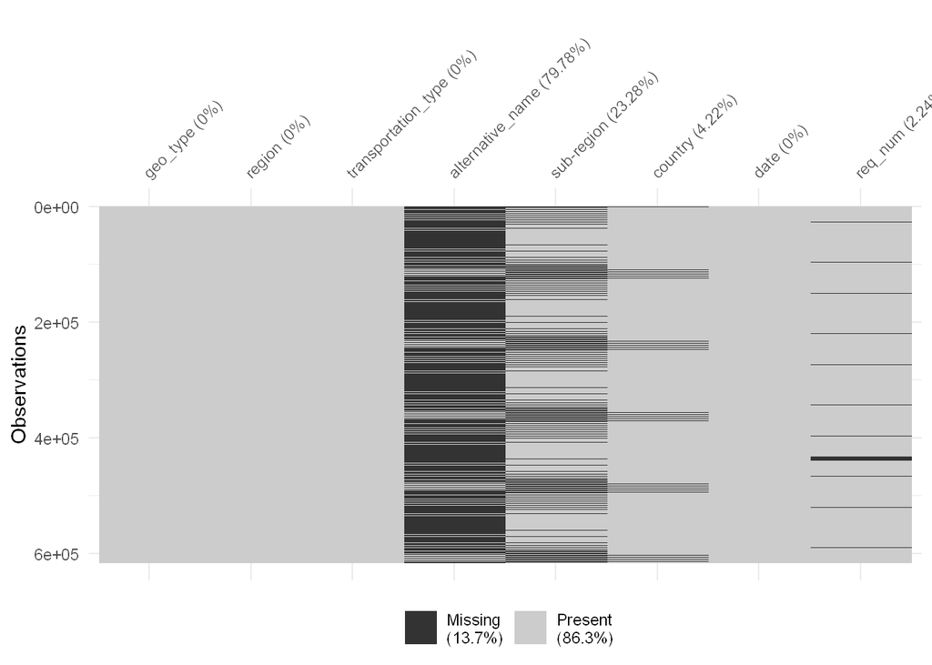

```r
vis_miss(mobility, warn_large_data = F) #from "visdat" Package
```

#### Remove the rows with missing data from the “request counts” coloumn

```r
new_mob <- mobility %>% filter(!is.na(req_num))  #from dplyr library

#test again for NA values
sum(is.na(new_mob$req_num))
```

```
## [1] 0
```

#### Removing the the “alternative_name” column

Here in our dataset, the “alternative_name” column is not important in our analysis, so we gonna remove it.

```r
mobility <- mobility %>% select(-alternative_name)
#with select function, we can choose specific coloumns. Here, I put - sign to remove this coloumn from the data and store it in the same name of the object 'mobilty' which means I overwrited the dataframe
head(mobility)
```

```
## # A tibble: 6 x 7
##   geo_type     region   transportation_ty~ `sub-region` country date     req_num
##   <chr>        <chr>    <chr>              <chr>        <chr>   <chr>      <dbl>
## 1 country/reg~ Albania  driving            <NA>         <NA>    2020-01~     100
## 2 country/reg~ Albania  walking            <NA>         <NA>    2020-01~     100
## 3 country/reg~ Argenti~ driving            <NA>         <NA>    2020-01~     100
## 4 country/reg~ Argenti~ walking            <NA>         <NA>    2020-01~     100
## 5 country/reg~ Austral~ driving            <NA>         <NA>    2020-01~     100
## 6 country/reg~ Austral~ transit            <NA>         <NA>    2020-01~     100
```

#### Investigate the remaining columns with colnames function

```r
colnames(mobility)
```

```
## [1] "geo_type"            "region"              "transportation_type"
## [4] "sub-region"          "country"             "date"
## [7] "req_num"
```

from the first blick we can see that sub-region is a bad naming it is not good to use ‘-’ minus sign because this may cause errors ,instead we gonna use underscore ’_’.

#### Rename the “sub-region” coloumn

```r
mobility <- rename(mobility, sub_region = "sub-region") #from dplyr library
```

#### Change position of “region” coloumn

region column is considered to be our observations. Therefore, we gonna make it the first coumn.

```r
mobility <- mobility %>% relocate(region)
head(mobility)
```

```
## # A tibble: 6 x 7
##   region    geo_type      transportation_ty~ sub_region country date     req_num
##   <chr>     <chr>         <chr>              <chr>      <chr>   <chr>      <dbl>
## 1 Albania   country/regi~ driving            <NA>       <NA>    2020-01~     100
## 2 Albania   country/regi~ walking            <NA>       <NA>    2020-01~     100
## 3 Argentina country/regi~ driving            <NA>       <NA>    2020-01~     100
## 4 Argentina country/regi~ walking            <NA>       <NA>    2020-01~     100
## 5 Australia country/regi~ driving            <NA>       <NA>    2020-01~     100
## 6 Australia country/regi~ transit            <NA>       <NA>    2020-01~     100
```

#### Investigate the structure of mobility

to examine the structure of the the dataset

```r
str(mobility)
```

```
## tibble[,7] [616,250 x 7] (S3: tbl_df/tbl/data.frame)
##  $ region             : chr [1:616250] "Albania" "Albania" "Argentina" "Argentina" ...
##  $ geo_type           : chr [1:616250] "country/region" "country/region" "country/region" "country/region" ...
##  $ transportation_type: chr [1:616250] "driving" "walking" "driving" "walking" ...
##  $ sub_region         : chr [1:616250] NA NA NA NA ...
##  $ country            : chr [1:616250] NA NA NA NA ...
##  $ date               : chr [1:616250] "2020-01-13" "2020-01-13" "2020-01-13" "2020-01-13" ...
##  $ req_num            : num [1:616250] 100 100 100 100 100 100 100 100 100 100 ...
```

We can see that this object is a data frame or tibble with 7 columns, and the data type of these variables is numeric for req_num and charachter for the rest. Therefore we have to handle this

```r
class(mobility$region)
```

```
## [1] "character"
```

#### Variables constraints

in this step, we will convert the variables data types to the proper one

```r
mobility$geo_type <- as.factor(mobility$geo_type )
mobility$transportation_type <- as.factor(mobility$transportation_type)
mobility$date <- as.Date(mobility$date)
```

#### Accessing components of the factor Transportation type

```r
levels(mobility$transportation_type)
```

```
## [1] "driving" "transit" "walking"
```

#### Accessing components of the factor geo type

```r
levels(mobility$geo_type)
```

```
## [1] "city"           "country/region" "county"         "sub-region"
```

#### Summary statistics

for numeric data we want to know for example the central tendency (mean, median and mode) also, to know the variablity of our data like range, min, max (spread of the data) so, we can use fivenum function or summary function

```r
summary(mobility )
```

```
##     region                    geo_type      transportation_type
##  Length:616250      city          :133620   driving:518160
##  Class :character   country/region: 26010   transit: 37740
##  Mode  :character   county        :355300   walking: 60350
##                     sub-region    :101320
##
##
##
##   sub_region          country               date               req_num
##  Length:616250      Length:616250      Min.   :2020-01-13   Min.   :   2.43
##  Class :character   Class :character   1st Qu.:2020-02-24   1st Qu.:  77.26
##  Mode  :character   Mode  :character   Median :2020-04-06   Median : 103.22
##                                        Mean   :2020-04-06   Mean   : 106.52
##                                        3rd Qu.:2020-05-19   3rd Qu.: 127.77
##                                        Max.   :2020-06-30   Max.   :1370.08
##                                                             NA's   :13802
```

From this summary we can see that most of the regions is located in the united states as we might know one of the biggest market in the World to invest, so we gonna pick The Unites states. And from Europe we gonna select the biggest economic country in Europe which is Germany. Also, we have to take into consideration the Southern hemisphere. Because, The seasons of the year differ in the southern and northern hemispheres, and this can affect in some way the Covid situation and affect the behavior of mobility at the same time of the year. Brazil is one of the best developing country to choose with the biggest Population in South America. So, We will begin our analysis to see if these Potenial Markets is the right to target.

#### Selecting US, Germany and Brazil

```r
#Using filter func from dplyr package with the logical operator or "|" to select our chosen countries
target_market <- filter(mobility, region == "Germany"| region == "United States" | region == "Brazil")
```

Investigate the first 6 rows

```r
head(target_market)
```

```
## # A tibble: 6 x 7
##   region  geo_type      transportation_ty~ sub_region country date       req_num
##   <chr>   <fct>         <fct>              <chr>      <chr>   <date>       <dbl>
## 1 Brazil  country/regi~ driving            <NA>       <NA>    2020-01-13     100
## 2 Brazil  country/regi~ transit            <NA>       <NA>    2020-01-13     100
## 3 Brazil  country/regi~ walking            <NA>       <NA>    2020-01-13     100
## 4 Germany country/regi~ driving            <NA>       <NA>    2020-01-13     100
## 5 Germany country/regi~ transit            <NA>       <NA>    2020-01-13     100
## 6 Germany country/regi~ walking            <NA>       <NA>    2020-01-13     100
```

#### Investigate the last 6 rows

```r
tail(target_market)
```

```
## # A tibble: 6 x 7
##   region     geo_type    transportation_t~ sub_region country date       req_num
##   <chr>      <fct>       <fct>             <chr>      <chr>   <date>       <dbl>
## 1 Germany    country/re~ driving           <NA>       <NA>    2020-06-30   130.
## 2 Germany    country/re~ transit           <NA>       <NA>    2020-06-30   109.
## 3 Germany    country/re~ walking           <NA>       <NA>    2020-06-30   122.
## 4 United St~ country/re~ driving           <NA>       <NA>    2020-06-30   132.
## 5 United St~ country/re~ transit           <NA>       <NA>    2020-06-30    49.8
## 6 United St~ country/re~ walking           <NA>       <NA>    2020-06-30   115.
```

#### Checking the data types of our data

```r
sapply(target_market, class)
```

```
##              region            geo_type transportation_type          sub_region
##         "character"            "factor"            "factor"         "character"
##             country                date             req_num
##         "character"              "Date"           "numeric"
```

so everything is ok, we can proceed our analysis

### Summary statistics

for numeric data we want to know for example the central tendency (mean, median and mode) also, to know the variablity of our data like range, min, max (spread of the data) so, we can use fivenum function or summary function

```r
#summary for all chosen countries
summary(target_market$req_num)
```

```
##    Min. 1st Qu.  Median    Mean 3rd Qu.    Max.    NA's
##   15.71   48.72   84.14   78.94  105.59  171.31      18
```

Summary for requests number of maps in the United States

```r
us <- filter(target_market, region == "United States")
summary(us$req_num)
```

```
##    Min. 1st Qu.  Median    Mean 3rd Qu.    Max.    NA's
##   19.06   49.81   91.94   81.58  107.54  162.45       6
```

Summary for requests number of maps in Germany

```r
ger <- filter(target_market, region == "Germany")
summary(ger$req_num)
```

```
##    Min. 1st Qu.  Median    Mean 3rd Qu.    Max.    NA's
##   29.10   65.80   96.98   89.41  110.61  161.49       6
```

Summary for requests number of maps in Brazil

```r
br <- filter(target_market, region == "Brazil")
summary(br$req_num)
```

```
##    Min. 1st Qu.  Median    Mean 3rd Qu.    Max.    NA's
##   15.71   36.61   60.34   65.84   97.97  171.31       6
```

for the categorical data it is common to use frequency tables for examlple we want to get the total count of observations that fall in transportation_type

```r
table(target_market$transportation_type)
```

```
##
## driving transit walking
##     510     510     510
```

seems to be the same. we can see this in a barplot

```r
levels(us$transportation_type)
```

```
## [1] "driving" "transit" "walking"
```

#### univariate qualitative analysis

#### analysis of a single categorical variable-

##### Frequency bar chart-

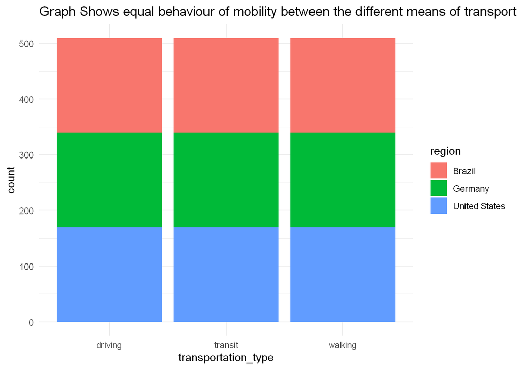

```r
#plot barplot fro the transportaion type
ggplot(target_market, aes(x=transportation_type)) +
  geom_bar(aes(fill=region))+ #use fill arg in aestestics enables us to choose the filled color depend on the region
  ggtitle("Graph Shows equal behaviour of mobility between the different means of transport")+
  theme_minimal() # prefer to choose the minimal theme for better Visualisation not to disratct our Audience wth useless stuff
```

so we wanna adjust our Product to fit the different types of transport. this may be easy to think that we are dealing with same kind , but may be challenging as well. because we have to take into account different transport types

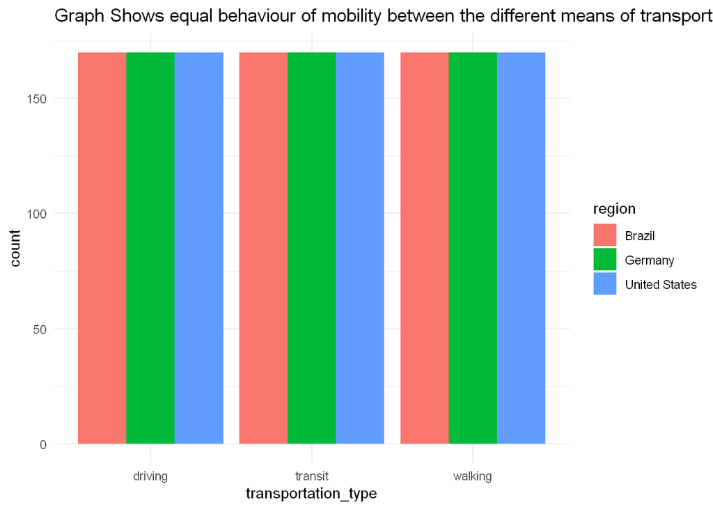

```r
#plot barplot fro the transportaion type
ggplot(target_market, aes(x=transportation_type)) +
  geom_bar(aes(fill=region), position = "dodge")+ #use fill arg in aestestics enables us to choose the filled color depend on the region
  ggtitle("Graph Shows equal behaviour of mobility between the different means of transport")+
  theme_minimal() # prefer to choose the minimal theme for better Visualisation not to disratct our Audience with useless stuff
```

##### quantitative univariate analysis–

analysis of a single numeric variable- measure of the location of the data(central tendency), spread of the data, shape. ———————————————————————————-

with boxplot we can see 5-number summary statistics for a single quantitative variables

###### create a box plot of number of requests of the maps

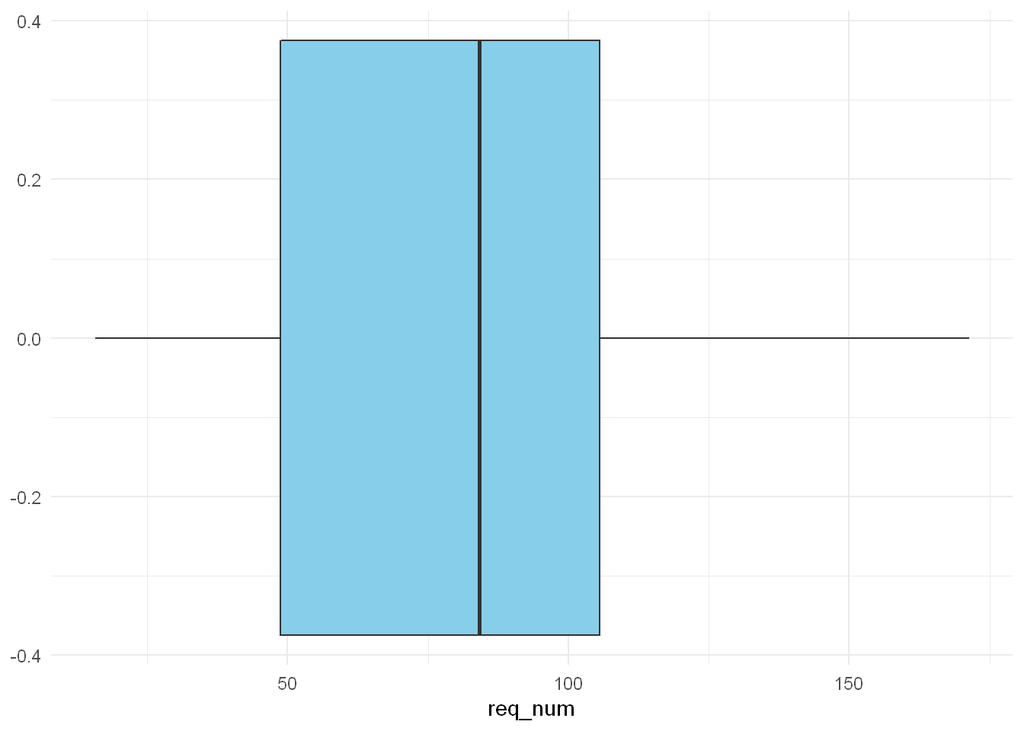

```r
ggplot(target_market, aes(x=req_num)) +
  geom_boxplot(fill="sky blue")+
  theme_minimal()
```

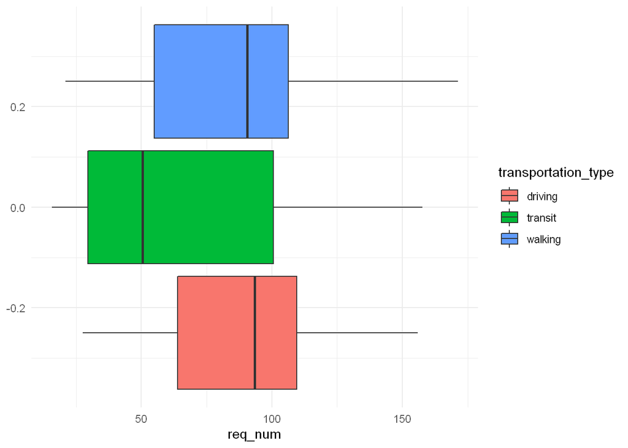

```r
ggplot(target_market, aes(x=req_num)) +
  geom_boxplot(aes(fill=transportation_type))+
  theme_minimal()
```

for better communications from our graphs we have to take in to conseideration , scales, semantic labelling instead of describing the relationship of the graph

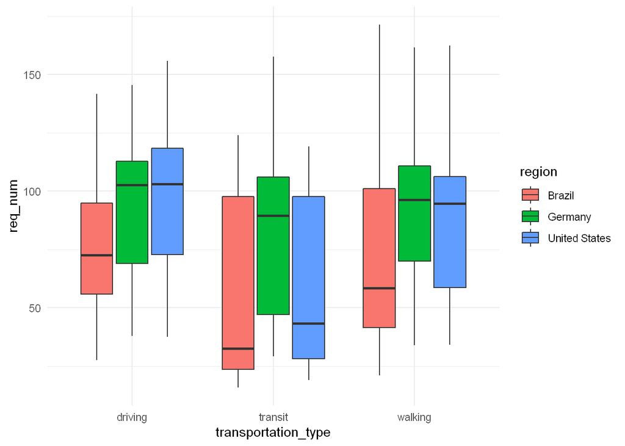

```r
ggplot(target_market, aes(x=transportation_type, y=req_num)) +
  geom_boxplot(aes(fill=region))+
  theme_minimal()
```

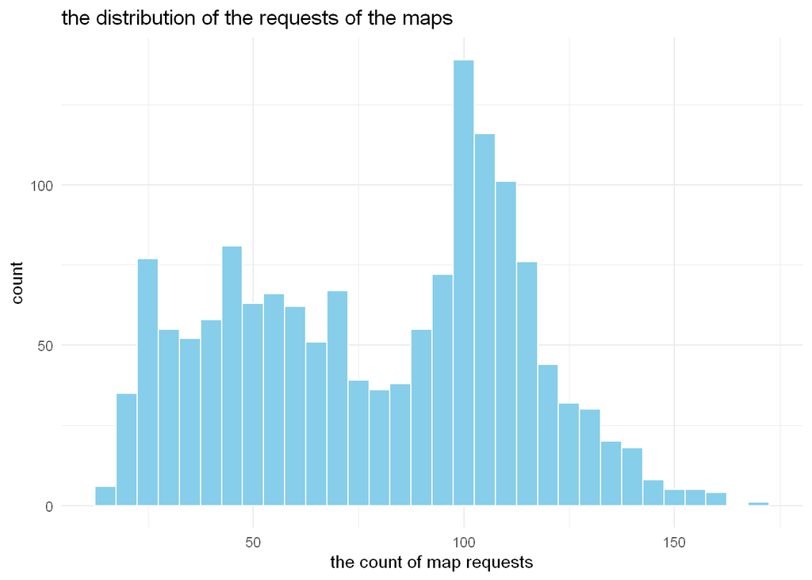

```r
#plot barplot from the transportaion type
ggplot(target_market, aes(x=req_num)) +
  geom_histogram(fill="skyblue", color = "white", binwidth = 5)+
  labs(title="the distribution of the requests of the maps ", x = "the count of map requests")+
  theme_minimal()
```

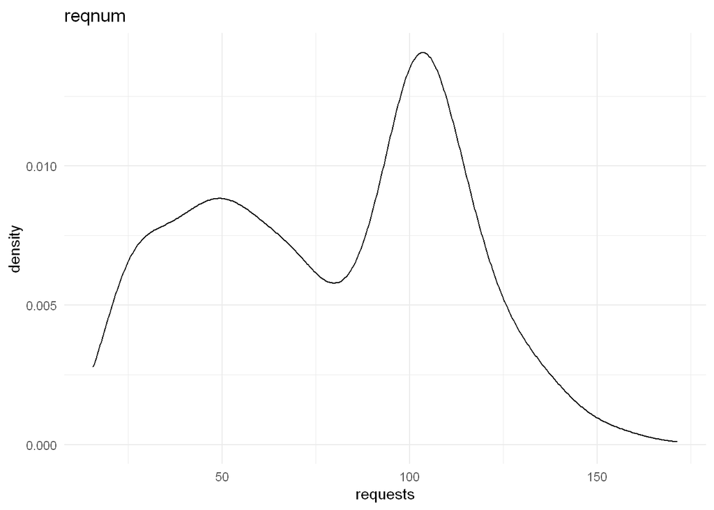

```r
ggplot(target_market, aes(x = req_num)) +
  geom_density() +
  labs(title = "reqnum",
       x = "requests") +
  theme_minimal()
```

#Time series

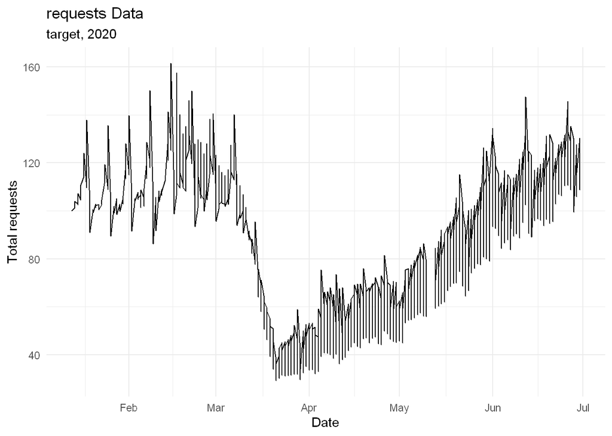

```r
# plot the data using ggplot
ggplot(ger, aes(x = date, y = req_num)) +
  geom_line() +
  labs(x = "Date",
    y = "Total requests",
    title = "requests Data",
    subtitle = "target, 2020")+
  theme_minimal()
```

from the graph we can see that behaviour of the people reduced dramatically during the pandemic in Mars and April

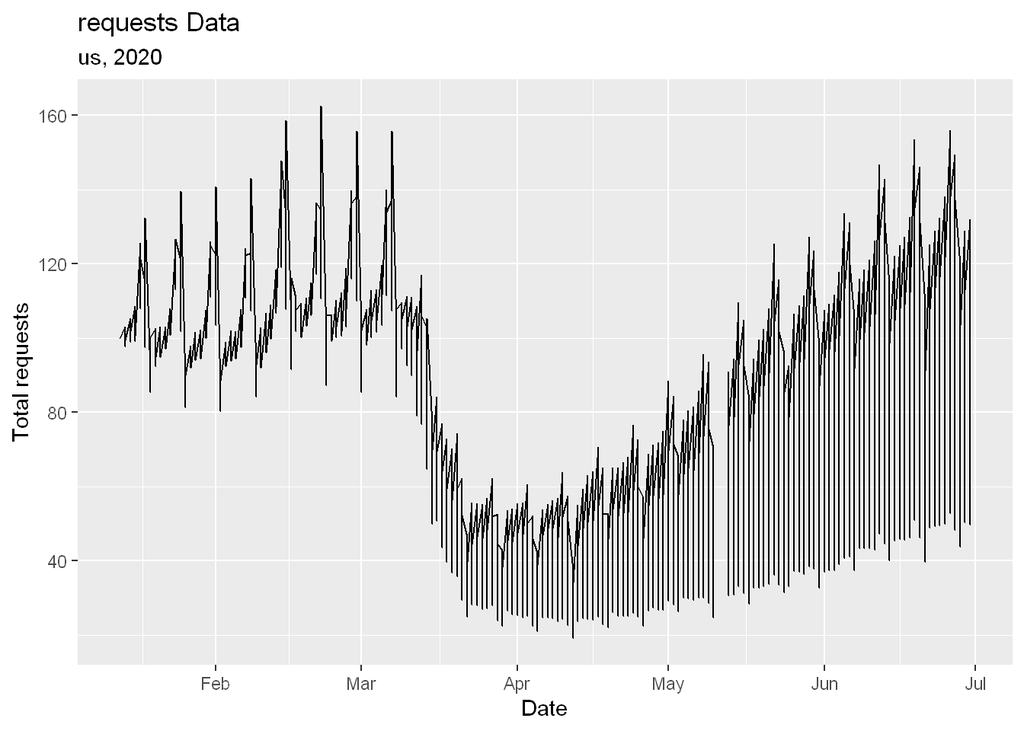

```r
# united states
ggplot(data = us, aes(x = date, y = req_num)) +
  geom_line() +
  labs(x = "Date",
    y = "Total requests",
    title = "requests Data",
    subtitle = "us, 2020")
```

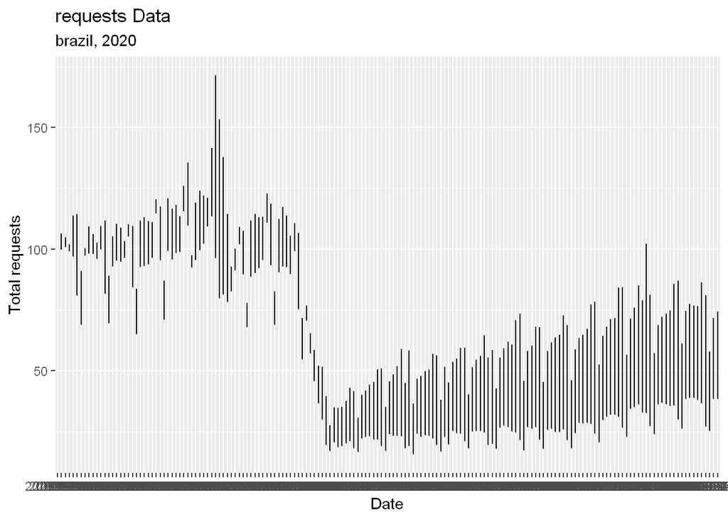

```r
br <- filter(new_mob, region == "Brazil")
ggplot(data = br, aes(x = date, y = req_num)) +
  geom_line() +
  labs(x = "Date",
    y = "Total requests",
    title = "requests Data",
    subtitle = "brazil, 2020")
```

Driving

[figure not shown]

```r
# plot the data using ggplot
drv <- filter(target_market,transportation_type=="driving")
ggplot(data = drv, aes(x = date, y = req_num )) +
  geom_line(aes(color =  region )) +
  labs(x = "Date",
    y = "Total requests",
    title = "requests Data",
    subtitle = "german cities, 2020")+
    theme_minimal()
```